# Real Data Analysis

Na Bo and Yue Wei

This file gives codes of real data analysis and reproducing plots and tables. The following contents are organized as:  
section 1: AREDS data analysis. We provide example code of running R-T, R-X, B-T, B-X, D-T, D-X and CSF. But since we do not provide full real data, we will commented these codes out and load intermediate results to reproduce plots and tables in the manuscript.

section 2: AREDS2 data analysis. We provide example code of running R-T, R-X, B-T, B-X, D-T, D-X and CSF. But since we do not provide full real data, we will commented these codes out and load intermediate results to reproduce plots and tables in the manuscript.

Please set up your working directory using code: your_directory <- setwd(“Your directory of ‘RealDataAnalysis’ folder”).

# 1 AREDS data analysis

This section provides example codes of running R-T, R-X, B-T, B-X, D-T, D-X and CSF and intermediate results to reproduce plots and tables in the manuscript.

## 1.1 Example code of running R-T, R-X, B-T, B-X, D-T, D-X and CSF in real data

We give an example code of running R-T, R-X, B-T, B-X, D-T, D-X and CSF on AREDS data when time of interest is 5 years. Since we do not share the full dataset, codes in this section are commented out and are served as an example of running functions on real data.

For 3 years, please change the “tt” in the following code.

```r
# time of interest
#tt <- 5 # change time of interest
```

Change your working director using code: your_directory <- setwd(“Your directory of folder ‘RealDataAnalysis’”)

To run D-T and D-X in R, we call tensorflow in Python from R. It requires the following steps:

- Please install Anaconda on your computer. [Instructions can be found here:] (https://docs.anaconda.com/anaconda/install/index.html).
- In R, please install “reticulate”, “tensorflow”, and “keras” in R using the following codes if you haven’t.

```r
#install.packages("reticulate")
#install.packages("tensorflow")
#install.packages("keras")
```

- open terminal
- type: conda activate r-reticulate
- back to Rstudio
- type code: source(“Your directory/DNNSurv_HTE_survival.R”)
- Procedures might differ in Windows or mac systems.

Load packages and functions:

```r
### load packages and functions for calling Python in R
# call tensorflow and keras
#library(reticulate)
#use_condaenv("r-reticulate")
#library(tensorflow)
#library(keras)

# check if tensorflow is successfully called
#tf$config$experimental_run_functions_eagerly(TRUE)
#tf$constant("Hello Tensorflow")

# check env of python, keras, numpy, tensorflow are under r-reticulate
#py_config()
#py_discover_config("keras")
#py_discover_config("numpy")
#py_discover_config("tensorflow")

### load other packages and functions
#library(survival)
#library(BART)
#library(randomForestSRC)
#library(tidyverse)
#library(gbm)
#library(randomForest)
#library(pec)
#library(AFTrees)
#library(mgcv)
#library(Boruta)
#source(paste0(your_directory,"/source_files/rsf_HTE_survival.R"))
#source(paste0(your_directory,"/source_files/aft_bart_np_SurvivalProb.R"))
#source(paste0(your_directory,"/source_files/aft_bart_np_survival.R"))
#source(paste0(your_directory,"/source_files/fun_util.R"))
#source(paste0(your_directory,"/source_files/DNNSurv_HTE_survival.R"))
```

Load the dataset (data not provided):

```r
#load("AREDS.RData") # loaded data name is dat_noID.
```

Split data with three random splits (Plase install splitTools package if you haven’t.):

```r
#install.packages("splitTools")
```

```r
#library(splitTools)
#set.seed(15213)
#folds1<-create_folds(dat_noID$Treatment,k=4,type="stratified")
#set.seed(130000)
#folds2<-create_folds(dat_noID$Treatment,k=4,type="stratified")
#set.seed(100871)
#folds3<-create_folds(dat_noID$Treatment,k=4,type="stratified")
#folds<-list(folds1,folds2,folds3)
```

The following codes are examples of running 4-fold CV for three splits using R-T, R-X, B-T, B-X, D-T, D-X and CSF at time.interest=5.

```r
#rsf_Tmid<-rsf_Xmid<-baft_Tmid<-baft_Xmid<-deepsurv_Tmid<-deepsurv_Xmid<-NULL
#rsf_T<-rsf_X<-baft_T<-baft_X<-deepsurv_T<-deepsurv_X<-vector(mode = "list", length = 3)
#ID<-c(1:806)

# R-T, R-X, B-T, B-X, D-T, D-X
#for (i in 1:3){
#  for (j in 1:4){
#    rsf_t<-rsf_HTE_T(data=dat_noID[folds[[i]][[j]],],testdat=dat_noID[-folds[[i]][[j]],],time.interest = 5)
#    rsf_x<-rsf_HTE_X(data=dat_noID[folds[[i]][[j]],],testdat=dat_noID[-folds[[i]][[j]],],time.interest = 5,ntrees=1000)
#    baft_t<-baft_HTE_T(data=dat_noID[folds[[i]][[j]],],testdat=dat_noID[-folds[[i]][[j]],],time.interest = 5)
#    baft_x<-baft_HTE_X(data=dat_noID[folds[[i]][[j]],],testdat=dat_noID[-folds[[i]][[j]],],time.interest = 5,ntrees=1000)
#    deepsurv_t<-DNNsurv_HTE_T(data=dat_noID[folds[[i]][[j]],],testdat=dat_noID[-folds[[i]][[j]],],time.interest = 5)
#    deepsurv_x<-DNNsurv_HTE_X(data=dat_noID[folds[[i]][[j]],],testdat=dat_noID[-folds[[i]][[j]],],time.interest = 5,ntrees=1000)
#    ID1<-ID[-folds[[i]][[j]]]
#    rsf_Tmid<-rbind(rsf_Tmid,cbind(ID1,rsf_t$diff))
#    rsf_Xmid<-rbind(rsf_Xmid,cbind(ID1,rsf_x$diff))
#    baft_Tmid<-rbind(baft_Tmid,cbind(ID1,baft_t$diff))
#    baft_Xmid<-rbind(baft_Xmid,cbind(ID1,baft_x$diff))
#    deepsurv_Tmid<-rbind(deepsurv_Tmid,cbind(ID1,deepsurv_t$diff))
#    deepsurv_Xmid<-rbind(deepsurv_Xmid,cbind(ID1,deepsurv_x$diff))
#  }
#  rsf_T[[i]]<-rsf_Tmid[,2][order(rsf_Tmid[,1])]
#  rsf_X[[i]]<-rsf_Xmid[,2][order(rsf_Xmid[,1])]
#  baft_T[[i]]<-baft_Tmid[,2][order(baft_Tmid[,1])]
#  baft_X[[i]]<-baft_Xmid[,2][order(baft_Xmid[,1])]
#  deepsurv_T[[i]]<-deepsurv_Tmid[,2][order(deepsurv_Tmid[,1])]
#  deepsurv_X[[i]]<-deepsurv_Xmid[,2][order(deepsurv_Xmid[,1])]
#  rsf_Tmid<-rsf_Xmid<-baft_Tmid<-baft_Xmid<-deepsurv_Tmid<-deepsurv_Xmid<-NULL
#}

#save(deepsurv_T,file=paste0(your_directory,"/intermediate_result/deepsurv_T_5Yrs.RData"))
#save(deepsurv_X,file=paste0(your_directory,"/intermediate_result/deepsurv_X_5Yrs.RData"))
#save(rsf_T,rsf_X,baft_T,baft_X,baft_X1,file=paste0(your_directory,"/intermediate_result/rsf_baft_results_5Yrs.RData"))

# CSF
#library(grf)
#for (i in 1:3){
#  for (j in 1:4){
#    csf<-causal_survival_forest(dat_noID[folds[[i]][[j]],-which(names(dat_noID)%in%c("Time","Event","Treatment"))],dat_noID[folds[[i]][[j]],which(names(dat_noID)%in%c("Time"))],dat_noID[folds[[i]][[j]],which(names(dat_noID)%in%c("Treatment"))],dat_noID[folds[[i]][[j]],which(names(dat_noID)%in%c("Event"))],target = "survival.probability",horizon = 5,num.trees = 500,mtry = (10/3),min.node.size = 15,num.threads=1)
#    csf_diff= predict(csf,dat_noID[-folds[[i]][[j]],-which(names(dat_noID)%in%c("Time","Event","Treatment"))])
#    ID1<-ID[-folds[[i]][[j]]]
#    csf_mid<-rbind(csf_mid,cbind(ID1,csf_diff))
#  }
#  csf_result[[i]]<-csf_mid[,2][order(csf_mid[,1])]
#  csf_mid<-NULL
#}
#save(csf_result,file=paste0(your_directory,"/intermediate_result/csf_5Yrs.RData"))
```

## 1.2 Example code of variable importance

Since we do not share the full data, the following codes give an example of variable importance based on treatment recommendation from D-X, using Boruta algorithm in section 4.3 of the manuscript. Annotated intermediate results are saved under “RealDataAnalysis/intermediate_result”. We also save CE4 SNP names under “RealDataAnalysis/intermediate_result/ce4SNPs.RData”.

Install Boruta package if you haven’t:

```r
#install.packages("Boruta")
```

Load Boruta:

```r
#library(Boruta)
```

Run Boruta in 3 splits of the data:

```r
#dat_noID$target1DNNsurvX<-ifelse(deepsurv_X[[1]]>=0,1,0)
#dat_noID$target2DNNsurvX<-ifelse(deepsurv_X[[2]]>=0,1,0)
#dat_noID$target3DNNsurvX<-ifelse(deepsurv_X[[3]]>=0,1,0)
#colnames(dat_noID)[695:697] <- c("target1","target2","target3")

#dat_rf1<-dat_noID[,c(1:6,9:695)]
#dat_rf2<-dat_noID[,c(1:6,9:694,696)]
#dat_rf3<-dat_noID[,c(1:6,9:694,697)]

#library(Boruta)
#set.seed(15213)
#boruta1<-Boruta(as.factor(target1)~.,data=dat_rf1,getImp=getImpRfZ)
#boruta2<-Boruta(as.factor(target2)~.,data=dat_rf2,getImp=getImpRfZ)
#boruta3<-Boruta(as.factor(target3)~.,data=dat_rf3,getImp=getImpRfZ)

#check1<-attStats(boruta1)
#check2<-attStats(boruta2)
#check3<-attStats(boruta3)

#top_var1 <- check1[which(check1$decision=="Confirmed"),]
#top_var1 <- top_var1[order(top_var1$meanImp,decreasing = T),]
#top_var1 <- cbind(rownames(top_var1),top_var1)
#colnames(top_var1)[1] <- "SNP"
#plot(boruta1)

#top_var2 <- check2[which(check2$decision=="Confirmed"),]
#top_var2 <- top_var2[order(top_var2$meanImp,decreasing = T),]
#top_var2 <- cbind(rownames(top_var2),top_var2)
#colnames(top_var2)[1] <- "SNP"

#top_var3 <- check3[which(check3$decision=="Confirmed"),]
#top_var3 <- top_var3[order(top_var3$meanImp,decreasing = T),]
#top_var3 <- cbind(rownames(top_var3),top_var3)
#colnames(top_var3)[1] <- "SNP"

# save Boruta intermediate results
#require(openxlsx)
#list_of_datasets <- list("split1" = top_var1, "split2" = top_var2,"split3" = top_var3)
#write.xlsx(list_of_datasets, file = "Your directory/Boruta_DNNsurv_X5Yrs.xlsx")

# This is the code for annotating SNPs. Since we do not provide annotation, we provide example code here.
#top_var1_annotated <- merge(annotation.freq,top_var1,by.x = "SNP",by.y = "SNP",all.y  = T)
#top_var2_annotated <- merge(annotation.freq,top_var2,by.x = "SNP",by.y = "SNP",all.y  = T)
#top_var3_annotated <- merge(annotation.freq,top_var3,by.x = "SNP",by.y = "SNP",all.y  = T)

# save annotated Boruta intermediate results
#require(openxlsx)
#list_of_datasets2 <- list("split1" = top_var1_annotated, "split2" = top_var2_annotated,"split3" = top_var3_annotated)
#write.xlsx(list_of_datasets2, file = "/Users/nab177/Box/DeepSubgroup/Survival/RealDatResults/AREDS_5Yrs/Boruta_DNNsurv_X_annotated.xlsx")

# save CE4 SNP names
#ce4SNPs<-colnames(dat_noID)[9:54]
#save(ce4SNPs,file =paste0(your_directory,"/intermediate_result/ce4SNPs.RData" ))
```

## 1.3 Reproduce tables and figures in the manuscript

This section provides codes for reproducing tables and figures in the manuscript. We have saved intermediate results (predicted CATE) under “RealDataAnalysis/intermediate_result” folder. As we do not provide full real data, figures and tables can be reproduced by loading intermediate results.

Please install the following packages if you haven’t :

```r
#install.packages("survival")
#install.packages(RColorBrewer)
```

Load packages:

```r
library(survival)
library(RColorBrewer)
```

### 1.3.1 Figure 3

Mean treatment effect in RT and RC group in 3 splits at year 5:

```r
# time of interest
tt <- 5

# load results of time=5
load(paste0(your_directory,"/intermediate_result/rsf_baft_results_5Yrs.RData"))
load(paste0(your_directory,"/intermediate_result/deepsurv_T_5Yrs.RData"))
load(paste0(your_directory,"/intermediate_result/deepsurv_X_5Yrs.RData"))
load(paste0(your_directory,"/intermediate_result/csf_5Yrs.RData"))

# load shared data
load(paste0(your_directory,"/data/AREDS_shared.RData"))

# RT group
rsf_T_KM<-rsf_X_KM<-baft_T_KM<-baft_X_KM<-baft_X1_KM<-deepsurv_T_KM<-deepsurv_X_KM<-csf_KM<-vector(mode = "list", length = 3)
rsf_T_KMse<-rsf_X_KMse<-baft_T_KMse<-baft_X_KMse<-baft_X1_KMse<-deepsurv_T_KMse<-deepsurv_X_KMse<-csf_KMse<-vector(mode = "list", length = 3)
rsf_T_KMno<-rsf_X_KMno<-baft_T_KMno<-baft_X_KMno<-baft_X1_KMno<-deepsurv_T_KMno<-deepsurv_X_KMno<-csf_KMno<-vector(mode = "list", length = 3)
rsf_T_KMnose<-rsf_X_KMnose<-baft_T_KMnose<-baft_X_KMnose<-baft_X1_KMnose<-deepsurv_T_KMnose<-deepsurv_X_KMnose<-csf_KMnose<-vector(mode = "list", length = 3)

for (i in 1:3){
  rsfT<-summary(survfit(Surv(Time, Event) ~ Treatment, data = AREDS_shared[which(rsf_T[[i]]>=0),]), times = tt)
  rsf_T_KM[[i]]<-rsfT$surv[2]-rsfT$surv[1]
  rsf_T_KMse[[i]]<-sqrt(rsfT$std.err[2]^2+rsfT$std.err[1]^2)
  rsfX<-summary(survfit(Surv(Time, Event) ~ Treatment, data = AREDS_shared[which(rsf_X[[i]]>=0),]), times = tt)
  rsf_X_KM[[i]]<-rsfX$surv[2]-rsfX$surv[1]
  rsf_X_KMse[[i]]<-sqrt(rsfX$std.err[2]^2+rsfX$std.err[1]^2)
  baftT<-summary(survfit(Surv(Time, Event) ~ Treatment, data = AREDS_shared[which(baft_T[[i]]>=0),]), times = tt)
  baft_T_KM[[i]]<-baftT$surv[2]-baftT$surv[1]
  baft_T_KMse[[i]]<-sqrt(baftT$std.err[2]^2+baftT$std.err[1]^2)
  baftX<-summary(survfit(Surv(Time, Event) ~ Treatment, data = AREDS_shared[which(baft_X[[i]]>=0),]), times = tt)
  baft_X_KM[[i]]<-baftX$surv[2]-baftX$surv[1]
  baft_X_KMse[[i]]<-sqrt(baftX$std.err[2]^2+baftX$std.err[1]^2)
  deepsurvT<-summary(survfit(Surv(Time, Event) ~ Treatment, data = AREDS_shared[which(deepsurv_T[[i]]>=0),]), times = tt)
  deepsurv_T_KM[[i]]<-deepsurvT$surv[2]-deepsurvT$surv[1]
  deepsurv_T_KMse[[i]]<-sqrt(deepsurvT$std.err[2]^2+deepsurvT$std.err[1]^2)
  deepsurvX<-summary(survfit(Surv(Time, Event) ~ Treatment, data = AREDS_shared[which(deepsurv_X[[i]]>=0),]), times = tt)
  deepsurv_X_KM[[i]]<-deepsurvX$surv[2]-deepsurvX$surv[1]
  deepsurv_X_KMse[[i]]<-sqrt(deepsurvX$std.err[2]^2+deepsurvX$std.err[1]^2)
  csf_surv<-summary(survfit(Surv(Time, Event) ~ Treatment, data = AREDS_shared[which(csf_result[[i]]>=0),]), times = 5)
  csf_KM[[i]]<-csf_surv$surv[2]-csf_surv$surv[1]
  csf_KMse[[i]]<-sqrt(csf_surv$std.err[2]^2+csf_surv$std.err[1]^2)
}

# RC group
for(i in 1:3){
  rsfTno<-summary(survfit(Surv(Time, Event) ~ Treatment, data = AREDS_shared[which(rsf_T[[i]]<0),]), times = tt)
  rsf_T_KMno[[i]]<-rsfTno$surv[2]-rsfTno$surv[1]
  rsf_T_KMnose[[i]]<-sqrt(rsfTno$std.err[2]^2+rsfTno$std.err[1]^2)
  rsfXno<-summary(survfit(Surv(Time, Event) ~ Treatment, data = AREDS_shared[which(rsf_X[[i]]<0),]), times = tt)
  rsf_X_KMno[[i]]<-rsfXno$surv[2]-rsfXno$surv[1]
  rsf_X_KMnose[[i]]<-sqrt(rsfXno$std.err[2]^2+rsfXno$std.err[1]^2)
  baftTno<-summary(survfit(Surv(Time, Event) ~ Treatment, data = AREDS_shared[which(baft_T[[i]]<0),]), times = tt)
  baft_T_KMno[[i]]<-baftTno$surv[2]-baftTno$surv[1]
  baft_T_KMnose[[i]]<-sqrt(baftTno$std.err[2]^2+baftTno$std.err[1]^2)
  baftXno<-summary(survfit(Surv(Time, Event) ~ Treatment, data = AREDS_shared[which(baft_X[[i]]<0),]), times = tt)
  baft_X_KMno[[i]]<-baftXno$surv[2]-baftXno$surv[1]
  baft_X_KMnose[[i]]<-sqrt(baftXno$std.err[2]^2+baftXno$std.err[1]^2)
  deepsurvTno<-summary(survfit(Surv(Time, Event) ~ Treatment, data = AREDS_shared[which(deepsurv_T[[i]]<0),]), times = tt)
  deepsurv_T_KMno[[i]]<-deepsurvTno$surv[2]-deepsurvTno$surv[1]
  deepsurv_T_KMnose[[i]]<-sqrt(deepsurvTno$std.err[2]^2+deepsurvTno$std.err[1]^2)
  deepsurvXno<-summary(survfit(Surv(Time, Event) ~ Treatment, data = AREDS_shared[which(deepsurv_X[[i]]<0),]), times = tt)
  deepsurv_X_KMno[[i]]<-deepsurvXno$surv[2]-deepsurvXno$surv[1]
  deepsurv_X_KMnose[[i]]<-sqrt(deepsurvXno$std.err[2]^2+deepsurvXno$std.err[1]^2)
  csf_survno<-summary(survfit(Surv(Time, Event) ~ Treatment, data = AREDS_shared[which(csf_result[[i]]<0),]), times = 5)
  csf_KMno[[i]]<-csf_survno$surv[2]-csf_survno$surv[1]
  csf_KMnose[[i]]<-sqrt(csf_survno$std.err[2]^2+csf_survno$std.err[1]^2)
}

allcombined<-c(unlist(rsf_T_KM),unlist(rsf_X_KM),unlist(baft_T_KM),unlist(baft_X_KM),unlist(deepsurv_T_KM),unlist(deepsurv_X_KM),unlist(csf_KM))
allcombinedse<-c(unlist(rsf_T_KMse),unlist(rsf_X_KMse),unlist(baft_T_KMse),unlist(baft_X_KMse),unlist(deepsurv_T_KMse),unlist(deepsurv_X_KMse),unlist(csf_KMse))

allcombined_no<-c(unlist(rsf_T_KMno),unlist(rsf_X_KMno),unlist(baft_T_KMno),unlist(baft_X_KMno),unlist(deepsurv_T_KMno),unlist(deepsurv_X_KMno),unlist(csf_KMno))
allcombined_nose<-c(unlist(rsf_T_KMnose),unlist(rsf_X_KMnose),unlist(baft_T_KMnose),unlist(baft_X_KMnose),unlist(deepsurv_T_KMnose),unlist(deepsurv_X_KMnose),unlist(csf_KMnose))
```

Overall mean treatment effect:

```r
fall <- survfit(Surv(Time, Event) ~ Treatment, data = AREDS_shared)
allresults<-summary(survfit(Surv(Time, Event) ~ Treatment, data = AREDS_shared), times = tt)
meandiff<-allresults$surv[2]-allresults$surv[1]
meandiffse<-sqrt(allresults$std.err[2]^2+allresults$std.err[1]^2)
```

Figure 3:

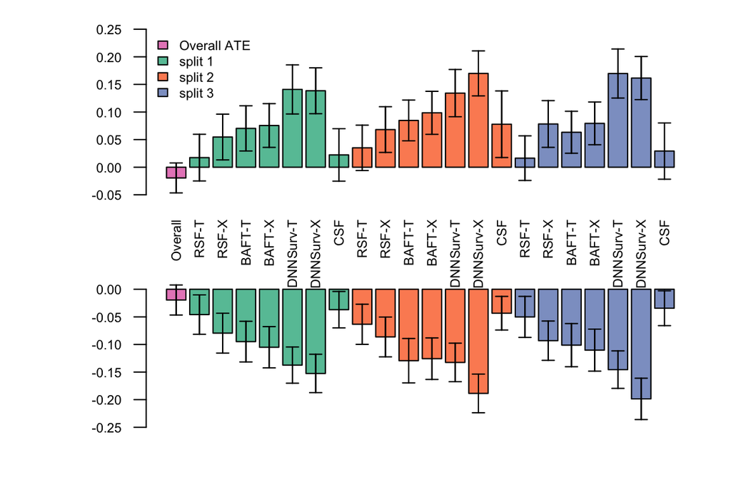

```r
colorcheck<-brewer.pal(4,"Set2")
par(mfrow=c(2,1))
par(mar = c(2, 6, 1.2, 1.5))
par(cex.lab=0.65)
par(cex.axis=0.65)
plotss<-barplot(height=c(meandiff,allcombined[c(1,4,7,10,13,16,19,2,5,8,11,14,17,20,3,6,9,12,15,18,21)]),names=c("Overall",rep(c("RSF-T","RSF-X","BAFT-T","BAFT-X","DNNSurv-T","DNNSurv-X","CSF"),3)),col=c(colorcheck[4],rep(colorcheck[1],7),rep(colorcheck[2],7),rep(colorcheck[3],7)),las=2,ylim=c(-0.05,0.25),cex.axis=0.65)
legend(x="topleft",fill=c(colorcheck[4],colorcheck[1],colorcheck[2],colorcheck[3]),legend = c("Overall ATE","split 1","split 2","split 3"),cex=0.65,bty = "n")
segments(plotss, c(meandiff,allcombined[c(1,4,7,10,13,16,19,2,5,8,11,14,17,20,3,6,9,12,15,18,21)]) - c(meandiffse,allcombinedse[c(1,4,7,10,13,16,19,2,5,8,11,14,17,20,3,6,9,12,15,18,21)]),
         plotss, c(meandiff,allcombined[c(1,4,7,10,13,16,19,2,5,8,11,14,17,20,3,6,9,12,15,18,21)]) + c(meandiffse,allcombinedse[c(1,4,7,10,13,16,19,2,5,8,11,14,17,20,3,6,9,12,15,18,21)]), lwd = 1)
arrows(plotss, c(meandiff,allcombined[c(1,4,7,10,13,16,19,2,5,8,11,14,17,20,3,6,9,12,15,18,21)]) - c(meandiffse,allcombinedse[c(1,4,7,10,13,16,19,2,5,8,11,14,17,20,3,6,9,12,15,18,21)]),
       plotss, c(meandiff,allcombined[c(1,4,7,10,13,16,19,2,5,8,11,14,17,20,3,6,9,12,15,18,21)]) + c(meandiffse,allcombinedse[c(1,4,7,10,13,16,19,2,5,8,11,14,17,20,3,6,9,12,15,18,21)]), lwd = 1, angle = 90,code = 3, length = 0.05)
plotss<-barplot(height=c(meandiff,allcombined_no[c(1,4,7,10,13,16,19,2,5,8,11,14,17,20,3,6,9,12,15,18,21)]),names=c("Overall",rep(c("RSF-T","RSF-X","BAFT-T","BAFT-X","DNNSurv-T","DNNSurv-X","CSF"),3)),col=c(colorcheck[4],rep(colorcheck[1],7),rep(colorcheck[2],7),rep(colorcheck[3],7)), las=2,ylim=c(-0.27,0.03),xaxt="n")
segments(plotss, c(meandiff,allcombined_no[c(1,4,7,10,13,16,19,2,5,8,11,14,17,20,3,6,9,12,15,18,21)]) - c(meandiffse,allcombined_nose[c(1,4,7,10,13,16,19,2,5,8,11,14,17,20,3,6,9,12,15,18,21)]),
         plotss, c(meandiff,allcombined_no[c(1,4,7,10,13,16,19,2,5,8,11,14,17,20,3,6,9,12,15,18,21)]) + c(meandiffse,allcombined_nose[c(1,4,7,10,13,16,19,2,5,8,11,14,17,20,3,6,9,12,15,18,21)]), lwd = 1,col="black")
arrows(plotss, c(meandiff,allcombined_no[c(1,4,7,10,13,16,19,2,5,8,11,14,17,20,3,6,9,12,15,18,21)]) - c(meandiffse,allcombined_nose[c(1,4,7,10,13,16,19,2,5,8,11,14,17,20,3,6,9,12,15,18,21)]),
       plotss, c(meandiff,allcombined_no[c(1,4,7,10,13,16,19,2,5,8,11,14,17,20,3,6,9,12,15,18,21)]) + c(meandiffse,allcombined_nose[c(1,4,7,10,13,16,19,2,5,8,11,14,17,20,3,6,9,12,15,18,21)]), lwd = 1, angle = 90,col="black",code = 3, length = 0.05)
```

The bars under split1 shows results in Figure 3; the bars under split2 and split3 shows results in Web Figure 7.

### 1.3.2 Variable importance (time of interest=5)

This section reproduces variable importance results in section 4.3 of the manuscript, using Boruta algorithm when treatment recommendation is based on D-X.

As we do not share the full data, we give an example code of reproducing the results in section 4.3 of the manuscript by loading intermediate results, which is saved under “RealDataAnalysis/intermediate_result”:

Load intermediate results:

```r
# load Borura algorithm results
library(readxl)
Boruta_DNNsurv_X5Yrs_split1 <- read_excel(paste0(your_directory,"/intermediate_result/Boruta_DNNsurv_X5Yrs.xlsx"), sheet = "split1")
Boruta_DNNsurv_X5Yrs_split2 <- read_excel(paste0(your_directory,"/intermediate_result/Boruta_DNNsurv_X5Yrs.xlsx"), sheet = "split2")
Boruta_DNNsurv_X5Yrs_split3 <- read_excel(paste0(your_directory,"/intermediate_result/Boruta_DNNsurv_X5Yrs.xlsx"), sheet = "split3")

# load CE4 SNP names:
load(paste0(your_directory,"/intermediate_result/ce4SNPs.RData"))
```

Number of important features in split 1 by Boruta:

```
## [1] 37
```

Number of important features in split 2 by Boruta:

```
## [1] 22
```

Number of important features in split 3 by Boruta:

```
## [1] 22
```

Important features across 3 splits:

```
## [1] 17
```

```
##  [1] "rs1056437"   "rs1871453"   "rs1618927"   "rs1245576"   "rs4747238"
##  [6] "rs149309589" "rs11626491"  "rs8111282"   "rs10407034"  "rs8108300"
## [11] "rs141380308" "rs8109218"   "rs10422229"  "rs147106198" "rs149894721"
## [16] "rs7140819"   "rs145003698"
```

### 1.3.3 Table 3 (upper panel)

This section reproduces genetic profile (Table 3 upper panel). Partial data shared is saved under “RealDataAnalysis/data”.

Install “Table1” package if you haven’t:

```r
#library(devtools)
#install_github("emwozniak/Table1")
```

Load library:

Load shared data:

```r
load(paste0(your_directory,"/data/AREDS_shared.RData"))
```

Table 3 (Upper panel) with Chi-squared tests: (0: AA; 1:Aa; 2:aa)

```r
load(paste0(your_directory,"/intermediate_result/deepsurv_X_5Yrs.RData"))
AREDS_shared$target1DNNsurvX<-ifelse(deepsurv_X[[1]]>=0,1,0)

catVars <- c("rs1245576", "rs8109218","rs147106198")

# Overall column
tab1 <- CreateTableOne(vars = catVars, data = AREDS_shared, factorVars = catVars)
tab1
```

```
##
##                   Overall
##   n               806
##   rs1245576 (%)
##      0            266 (33.0)
##      1            408 (50.6)
##      2            132 (16.4)
##   rs8109218 (%)
##      0            388 (48.1)
##      1            333 (41.3)
##      2             85 (10.5)
##   rs147106198 (%)
##      0            387 (48.0)
##      1            343 (42.6)
##      2             76 ( 9.4)
```

```r
# RT, RC and p columns
tab2 <- CreateTableOne(vars = catVars, strata = "target1DNNsurvX" , data = AREDS_shared, factorVars = catVars)
print(tab2, showAllLevels = TRUE,formatOptions = list(big.mark = ","))
```

```
##                  Stratified by target1DNNsurvX
##                   level 0           1           p      test
##   n                     436         370
##   rs1245576 (%)   0     199 (45.6)   67 (18.1)  <0.001
##                   1     205 (47.0)  203 (54.9)
##                   2      32 ( 7.3)  100 (27.0)
##   rs8109218 (%)   0     254 (58.3)  134 (36.2)  <0.001
##                   1     160 (36.7)  173 (46.8)
##                   2      22 ( 5.0)   63 (17.0)
##   rs147106198 (%) 0     249 (57.1)  138 (37.3)  <0.001
##                   1     168 (38.5)  175 (47.3)
##                   2      19 ( 4.4)   57 (15.4)
```

### 1.3.4 Results when time of interests = 3 years

Mean treatment effect in RT and RC group in 3 splits at year 3:

```r
# time of interest
tt <- 3

# load results of time=3
load(paste0(your_directory,"/intermediate_result/rsf_baft_results_3Yrs.RData"))
load(paste0(your_directory,"/intermediate_result/D_T_result_3Yrs.RData"))
load(paste0(your_directory,"/intermediate_result/D_X_result_3Yrs.RData"))
load(paste0(your_directory,"/intermediate_result/csf_3Yrs.RData"))

# load shared data
load(paste0(your_directory,"/data/AREDS_shared.RData"))

# RT group
rsf_T_KM<-rsf_X_KM<-baft_T_KM<-baft_X_KM<-baft_X1_KM<-deepsurv_T_KM<-deepsurv_X_KM<-csf_KM<-vector(mode = "list", length = 3)
rsf_T_KMse<-rsf_X_KMse<-baft_T_KMse<-baft_X_KMse<-baft_X1_KMse<-deepsurv_T_KMse<-deepsurv_X_KMse<-csf_KMse<-vector(mode = "list", length = 3)
rsf_T_KMno<-rsf_X_KMno<-baft_T_KMno<-baft_X_KMno<-baft_X1_KMno<-deepsurv_T_KMno<-deepsurv_X_KMno<-csf_KMno<-vector(mode = "list", length = 3)
rsf_T_KMnose<-rsf_X_KMnose<-baft_T_KMnose<-baft_X_KMnose<-baft_X1_KMnose<-deepsurv_T_KMnose<-deepsurv_X_KMnose<-csf_KMnose<-vector(mode = "list", length = 3)

for (i in 1:3){
  rsfT<-summary(survfit(Surv(Time, Event) ~ Treatment, data = AREDS_shared[which(rsf_T[[i]]>=0),]), times = tt)
  rsf_T_KM[[i]]<-rsfT$surv[2]-rsfT$surv[1]
  rsf_T_KMse[[i]]<-sqrt(rsfT$std.err[2]^2+rsfT$std.err[1]^2)
  rsfX<-summary(survfit(Surv(Time, Event) ~ Treatment, data = AREDS_shared[which(rsf_X[[i]]>=0),]), times = tt)
  rsf_X_KM[[i]]<-rsfX$surv[2]-rsfX$surv[1]
  rsf_X_KMse[[i]]<-sqrt(rsfX$std.err[2]^2+rsfX$std.err[1]^2)
  baftT<-summary(survfit(Surv(Time, Event) ~ Treatment, data = AREDS_shared[which(baft_T[[i]]>=0),]), times = tt)
  baft_T_KM[[i]]<-baftT$surv[2]-baftT$surv[1]
  baft_T_KMse[[i]]<-sqrt(baftT$std.err[2]^2+baftT$std.err[1]^2)
  baftX<-summary(survfit(Surv(Time, Event) ~ Treatment, data = AREDS_shared[which(baft_X[[i]]>=0),]), times = tt)
  baft_X_KM[[i]]<-baftX$surv[2]-baftX$surv[1]
  baft_X_KMse[[i]]<-sqrt(baftX$std.err[2]^2+baftX$std.err[1]^2)
  deepsurvT<-summary(survfit(Surv(Time, Event) ~ Treatment, data = AREDS_shared[which(D_T_result[[i]]>=0),]), times = tt)
  deepsurv_T_KM[[i]]<-deepsurvT$surv[2]-deepsurvT$surv[1]
  deepsurv_T_KMse[[i]]<-sqrt(deepsurvT$std.err[2]^2+deepsurvT$std.err[1]^2)
  deepsurvX<-summary(survfit(Surv(Time, Event) ~ Treatment, data = AREDS_shared[which(D_X_result[[i]]>=0),]), times = tt)
  deepsurv_X_KM[[i]]<-deepsurvX$surv[2]-deepsurvX$surv[1]
  deepsurv_X_KMse[[i]]<-sqrt(deepsurvX$std.err[2]^2+deepsurvX$std.err[1]^2)
  csf<-summary(survfit(Surv(Time, Event) ~ Treatment, data = AREDS_shared[which(csf_result[[i]]>=0),]), times = tt)
  csf_KM[[i]]<-csf$surv[2]-csf$surv[1]
  csf_KMse[[i]]<-sqrt(csf$std.err[2]^2+csf$std.err[1]^2)
}

# RC group
for(i in 1:3){
  rsfTno<-summary(survfit(Surv(Time, Event) ~ Treatment, data = AREDS_shared[which(rsf_T[[i]]<0),]), times = tt)
  rsf_T_KMno[[i]]<-rsfTno$surv[2]-rsfTno$surv[1]
  rsf_T_KMnose[[i]]<-sqrt(rsfTno$std.err[2]^2+rsfTno$std.err[1]^2)
  rsfXno<-summary(survfit(Surv(Time, Event) ~ Treatment, data = AREDS_shared[which(rsf_X[[i]]<0),]), times = tt)
  rsf_X_KMno[[i]]<-rsfXno$surv[2]-rsfXno$surv[1]
  rsf_X_KMnose[[i]]<-sqrt(rsfXno$std.err[2]^2+rsfXno$std.err[1]^2)
  baftTno<-summary(survfit(Surv(Time, Event) ~ Treatment, data = AREDS_shared[which(baft_T[[i]]<0),]), times = tt)
  baft_T_KMno[[i]]<-baftTno$surv[2]-baftTno$surv[1]
  baft_T_KMnose[[i]]<-sqrt(baftTno$std.err[2]^2+baftTno$std.err[1]^2)
  baftXno<-summary(survfit(Surv(Time, Event) ~ Treatment, data = AREDS_shared[which(baft_X[[i]]<0),]), times = tt)
  baft_X_KMno[[i]]<-baftXno$surv[2]-baftXno$surv[1]
  baft_X_KMnose[[i]]<-sqrt(baftXno$std.err[2]^2+baftXno$std.err[1]^2)
  deepsurvTno<-summary(survfit(Surv(Time, Event) ~ Treatment, data = AREDS_shared[which(D_T_result[[i]]<0),]), times = tt)
  deepsurv_T_KMno[[i]]<-deepsurvTno$surv[2]-deepsurvTno$surv[1]
  deepsurv_T_KMnose[[i]]<-sqrt(deepsurvTno$std.err[2]^2+deepsurvTno$std.err[1]^2)
  deepsurvXno<-summary(survfit(Surv(Time, Event) ~ Treatment, data = AREDS_shared[which(D_X_result[[i]]<0),]), times = tt)
  deepsurv_X_KMno[[i]]<-deepsurvXno$surv[2]-deepsurvXno$surv[1]
  deepsurv_X_KMnose[[i]]<-sqrt(deepsurvXno$std.err[2]^2+deepsurvXno$std.err[1]^2)
  csfno<-summary(survfit(Surv(Time, Event) ~ Treatment, data = AREDS_shared[which(csf_result[[i]]<0),]), times = tt)
  csf_KMno[[i]]<-csfno$surv[2]-csfno$surv[1]
  csf_KMnose[[i]]<-sqrt(csfno$std.err[2]^2+csfno$std.err[1]^2)
}

allcombined<-c(unlist(rsf_T_KM),unlist(rsf_X_KM),unlist(baft_T_KM),unlist(baft_X_KM),unlist(deepsurv_T_KM),unlist(deepsurv_X_KM),unlist(csf_KM))
allcombinedse<-c(unlist(rsf_T_KMse),unlist(rsf_X_KMse),unlist(baft_T_KMse),unlist(baft_X_KMse),unlist(deepsurv_T_KMse),unlist(deepsurv_X_KMse),unlist(csf_KMse))

allcombined_no<-c(unlist(rsf_T_KMno),unlist(rsf_X_KMno),unlist(baft_T_KMno),unlist(baft_X_KMno),unlist(deepsurv_T_KMno),unlist(deepsurv_X_KMno),unlist(csf_KMno))
allcombined_nose<-c(unlist(rsf_T_KMnose),unlist(rsf_X_KMnose),unlist(baft_T_KMnose),unlist(baft_X_KMnose),unlist(deepsurv_T_KMnose),unlist(deepsurv_X_KMnose),unlist(csf_KMnose))
```

Overall mean treatment effect:

```r
fall <- survfit(Surv(Time, Event) ~ Treatment, data = AREDS_shared)
allresults<-summary(survfit(Surv(Time, Event) ~ Treatment, data = AREDS_shared), times = tt)
meandiff<-allresults$surv[2]-allresults$surv[1]
meandiffse<-sqrt(allresults$std.err[2]^2+allresults$std.err[1]^2)
```

Web Figure 8:

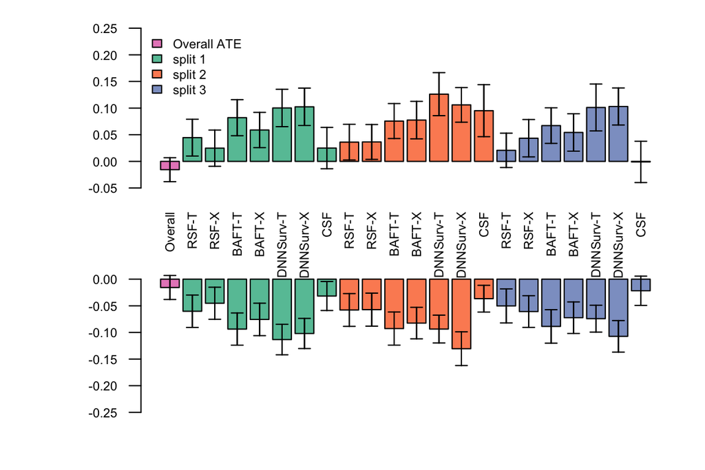

```r
colorcheck<-brewer.pal(4,"Set2")
par(mfrow=c(2,1))
par(mar = c(2, 6, 1.2, 1.5))
par(cex.lab=0.65)
par(cex.axis=0.65)
plotss<-barplot(height=c(meandiff,allcombined[c(1,4,7,10,13,16,19,2,5,8,11,14,17,20,3,6,9,12,15,18,21)]),names=c("Overall",rep(c("RSF-T","RSF-X","BAFT-T","BAFT-X","DNNSurv-T","DNNSurv-X","CSF"),3)),col=c(colorcheck[4],rep(colorcheck[1],7),rep(colorcheck[2],7),rep(colorcheck[3],7)),las=2,ylim=c(-0.05,0.25),cex.axis=0.65)
legend(x="topleft",fill=c(colorcheck[4],colorcheck[1],colorcheck[2],colorcheck[3]),legend = c("Overall ATE","split 1","split 2","split 3"),cex=0.65,bty = "n")
segments(plotss, c(meandiff,allcombined[c(1,4,7,10,13,16,19,2,5,8,11,14,17,20,3,6,9,12,15,18,21)]) - c(meandiffse,allcombinedse[c(1,4,7,10,13,16,19,2,5,8,11,14,17,20,3,6,9,12,15,18,21)]),
         plotss, c(meandiff,allcombined[c(1,4,7,10,13,16,19,2,5,8,11,14,17,20,3,6,9,12,15,18,21)]) + c(meandiffse,allcombinedse[c(1,4,7,10,13,16,19,2,5,8,11,14,17,20,3,6,9,12,15,18,21)]), lwd = 1)
arrows(plotss, c(meandiff,allcombined[c(1,4,7,10,13,16,19,2,5,8,11,14,17,20,3,6,9,12,15,18,21)]) - c(meandiffse,allcombinedse[c(1,4,7,10,13,16,19,2,5,8,11,14,17,20,3,6,9,12,15,18,21)]),
       plotss, c(meandiff,allcombined[c(1,4,7,10,13,16,19,2,5,8,11,14,17,20,3,6,9,12,15,18,21)]) + c(meandiffse,allcombinedse[c(1,4,7,10,13,16,19,2,5,8,11,14,17,20,3,6,9,12,15,18,21)]), lwd = 1, angle = 90,code = 3, length = 0.05)
plotss<-barplot(height=c(meandiff,allcombined_no[c(1,4,7,10,13,16,19,2,5,8,11,14,17,20,3,6,9,12,15,18,21)]),names=c("Overall",rep(c("RSF-T","RSF-X","BAFT-T","BAFT-X","DNNSurv-T","DNNSurv-X","CSF"),3)),col=c(colorcheck[4],rep(colorcheck[1],7),rep(colorcheck[2],7),rep(colorcheck[3],7)), las=2,ylim=c(-0.27,0.03),xaxt="n")
segments(plotss, c(meandiff,allcombined_no[c(1,4,7,10,13,16,19,2,5,8,11,14,17,20,3,6,9,12,15,18,21)]) - c(meandiffse,allcombined_nose[c(1,4,7,10,13,16,19,2,5,8,11,14,17,20,3,6,9,12,15,18,21)]),
         plotss, c(meandiff,allcombined_no[c(1,4,7,10,13,16,19,2,5,8,11,14,17,20,3,6,9,12,15,18,21)]) + c(meandiffse,allcombined_nose[c(1,4,7,10,13,16,19,2,5,8,11,14,17,20,3,6,9,12,15,18,21)]), lwd = 1,col="black")
arrows(plotss, c(meandiff,allcombined_no[c(1,4,7,10,13,16,19,2,5,8,11,14,17,20,3,6,9,12,15,18,21)]) - c(meandiffse,allcombined_nose[c(1,4,7,10,13,16,19,2,5,8,11,14,17,20,3,6,9,12,15,18,21)]),
       plotss, c(meandiff,allcombined_no[c(1,4,7,10,13,16,19,2,5,8,11,14,17,20,3,6,9,12,15,18,21)]) + c(meandiffse,allcombined_nose[c(1,4,7,10,13,16,19,2,5,8,11,14,17,20,3,6,9,12,15,18,21)]), lwd = 1, angle = 90,col="black",code = 3, length = 0.05)
```

### 1.3.5 Variable importance (time of interest=3)

This section reproduces variable importance results when time of interest=3, using Boruta algorithm when treatment recommendation is based on D-X.

As we do not share the full data, we give an example code of reproducing the results by loading intermediate results, which is saved under “RealDataAnalysis/intermediate_result”:

Load intermediate results:

```r
# load Borura algorithm results
library(readxl)
Boruta_DNNsurv_X3Yrs_split1 <- read_excel(paste0(your_directory,"/intermediate_result/Boruta_DNNsurv_X3Yrs.xlsx"), sheet = "split1")
Boruta_DNNsurv_X3Yrs_split2 <- read_excel(paste0(your_directory,"/intermediate_result/Boruta_DNNsurv_X3Yrs.xlsx"), sheet = "split2")
Boruta_DNNsurv_X3Yrs_split3 <- read_excel(paste0(your_directory,"/intermediate_result/Boruta_DNNsurv_X3Yrs.xlsx"), sheet = "split3")

# load CE4 SNP names:
load(paste0(your_directory,"/intermediate_result/ce4SNPs.RData"))
```

Number of important features in split 1 by Boruta:

```
## [1] 17
```

Number of important features in split 2 by Boruta:

```
## [1] 21
```

Number of important features in split 3 by Boruta:

```
## [1] 21
```

Important features across 3 splits:

```
## [1] 15
```

```
##  [1] "rs1245576"   "rs1871453"   "rs1618927"   "rs4747238"   "rs1056437"
##  [6] "rs10422229"  "rs8109218"   "rs141380308" "rs8108300"   "rs10407034"
## [11] "rs8111282"   "rs6574326"   "rs11626491"  "rs145003698" "rs149894721"
```

### 1.3.6 SNPs in common at time of interest=3 and time of interest=5

Load intermediate results at time of interest=3:

```r
# load Borura algorithm results
library(readxl)
Boruta_DNNsurv_X3Yrs_split1 <- read_excel(paste0(your_directory,"/intermediate_result/Boruta_DNNsurv_X3Yrs.xlsx"), sheet = "split1")
Boruta_DNNsurv_X3Yrs_split2 <- read_excel(paste0(your_directory,"/intermediate_result/Boruta_DNNsurv_X3Yrs.xlsx"), sheet = "split2")
Boruta_DNNsurv_X3Yrs_split3 <- read_excel(paste0(your_directory,"/intermediate_result/Boruta_DNNsurv_X3Yrs.xlsx"), sheet = "split3")

# load CE4 SNP names:
load(paste0(your_directory,"/intermediate_result/ce4SNPs.RData"))
```

Load intermediate results at time of interest=5:

```r
# load Borura algorithm results
library(readxl)
Boruta_DNNsurv_X5Yrs_split1 <- read_excel(paste0(your_directory,"/intermediate_result/Boruta_DNNsurv_X5Yrs.xlsx"), sheet = "split1")
Boruta_DNNsurv_X5Yrs_split2 <- read_excel(paste0(your_directory,"/intermediate_result/Boruta_DNNsurv_X5Yrs.xlsx"), sheet = "split2")
Boruta_DNNsurv_X5Yrs_split3 <- read_excel(paste0(your_directory,"/intermediate_result/Boruta_DNNsurv_X5Yrs.xlsx"), sheet = "split3")

# load CE4 SNP names:
load(paste0(your_directory,"/intermediate_result/ce4SNPs.RData"))
```

Important features time of interest=3 across 3 splits:

```
## [1] 15
```

Important features time of interest=5 across 3 splits:

```
## [1] 17
```

Overlapped SNPs between time of interest=3 and time of interest=5:

```
##  [1] "rs1245576"   "rs1871453"   "rs1618927"   "rs4747238"   "rs1056437"
##  [6] "rs10422229"  "rs8109218"   "rs141380308" "rs8108300"   "rs10407034"
## [11] "rs8111282"   "rs11626491"  "rs145003698" "rs149894721"
```

# 2 AREDS2 data analysis

This section provides example codes of validating findings from AREDS on AREDS2. Since we do not provide full data, we privde example codes of running D-X. Intermediate results are saved under “RealDataAnalysis/intermediate_result/5timesDXresults_AREDS2ExcludeSevere_Time5.RData” to reproduce plots and tables in the manuscript.

## 2.1 Example code of validating D-X in AREDS2

We give an example code of validating D-X on AREDS2 data when time of interest is 5 years. Since we do not share the full dataset, codes in this section are commented out and are served as an example of running functions on real data.

For 3 years, please change the “tt” in the following code.

```r
# time of interest
#tt <- 5 # change time of interest
```

Change your working director using code: your_directory <- setwd(“Your directory of folder ‘RealDataAnalysis’”)

To run D-X in R, we call tensorflow in Python from R. It requires the following steps:

- Please install Anaconda on your computer. [Instructions can be found here:] (https://docs.anaconda.com/anaconda/install/index.html).
- In R, please install “reticulate”, “tensorflow”, and “keras” in R using the following codes if you haven’t.

```r
#install.packages("reticulate")
#install.packages("tensorflow")
#install.packages("keras")
```

- open terminal
- type: conda activate r-reticulate
- back to Rstudio
- type code: source(“Your directory/DNNSurv_HTE_survival.R”)
- Procedures might differ in Windows or mac systems.

Load packages and functions:

```r
### load packages and functions for calling Python in R
# call tensorflow and keras
#library(reticulate)
#use_condaenv("r-reticulate")
#library(tensorflow)
#library(keras)

# check if tensorflow is successfully called
#tf$config$experimental_run_functions_eagerly(TRUE)
#tf$constant("Hello Tensorflow")

# check env of python, keras, numpy, tensorflow are under r-reticulate
#py_config()
#py_discover_config("keras")
#py_discover_config("numpy")
#py_discover_config("tensorflow")

### load other packages and functions
#library(survival)
#library(randomForestSRC)
#library(tidyverse)
#library(gbm)
#library(randomForest)
#library(pec)
#library(mgcv)
#source(paste0(your_directory,"/source_files/fun_util.R"))
#source(paste0(your_directory,"/source_files/DNNSurv_HTE_survival.R"))
```

Load the dataset (the loaded data name is dat_noID.):

```r
# load AREDS data
#load("AREDS.RData") # loaded data name is dat_noID.

# load AREDS2 data
#load("AREDS2_placebo_DX_noID.RData") # loaded data names is AREDS2_placebo_noID1
```

Run 5 times of D-X training on AREDS and predicting on AREDS2 at time.interest=5:

```r
## exclude severe patients
#AREDS2_placebo_noID1_exc <- AREDS2_placebo_noID1[-which(AREDS2_placebo_noID1$SevScaleBL==7 | AREDS2_placebo_noID1$SevScaleBL==8),]

### 1st time
#set.seed(12345)
#deepsurv_x_exc_time5<-DNNsurv_HTE_X(data=dat_noID,testdat=AREDS2_placebo_noID1_exc,time.interest = tt,ntrees=1000)
#length(which(deepsurv_x_exc_time5$diff>=0))

### 2nd time
#set.seed(160000)
#deepsurv_x_exc_time5_2<-DNNsurv_HTE_X(data=dat_noID,testdat=AREDS2_placebo_noID1_exc,time.interest = tt,ntrees=1000)
#length(which(deepsurv_x_exc_time5_2$diff>=0))

### 3rd time
#set.seed(143200)
#deepsurv_x_exc_time5_3<-DNNsurv_HTE_X(data=dat_noID,testdat=AREDS2_placebo_noID1_exc,time.interest = tt,ntrees=1000)
#length(which(deepsurv_x_exc_time5_3$diff>=0))

### 4th time
#set.seed(165422)
#deepsurv_x_exc_time5_4<-DNNsurv_HTE_X(data=dat_noID,testdat=AREDS2_placebo_noID1_exc,time.interest = tt,ntrees=1000)
#length(which(deepsurv_x_exc_time5_4$diff>=0))

### 5th time
#set.seed(172643)
#deepsurv_x_exc_time5_5<-DNNsurv_HTE_X(data=dat_noID,testdat=AREDS2_placebo_noID1_exc,time.interest = tt,ntrees=1000)
#length(which(deepsurv_x_exc_time5_5$diff>=0))

#newdat3 <- as.data.frame(cbind(deepsurv_x_exc_time5$diff,deepsurv_x_exc_time5_2$diff,deepsurv_x_exc_time5_3$diff,deepsurv_x_exc_time5_4$diff,deepsurv_x_exc_time5_5$diff))
#save(newdat3,file = paste0(your_directory,"/intermediate_result/5timesDXresults_AREDS2ExcludeSevere_Time5.RData"))
```

## 2.2 Reproduce tables and figures

In this section, we reproduce results in section 4.4 of the manuscript by loading the intermediate results saved under “RealDataAnalysis/intermediate_result/5timesDXresults_AREDS2ExcludeSevere_Time5.RData”.

Load intermediate results:

```r
load(paste0(your_directory,"/intermediate_result/5timesDXresults_AREDS2ExcludeSevere_Time5.RData")) # loaded data name is newdat3.
```

Load shared AREDS2 data:

```r
load(paste0(your_directory,"/data/AREDS2_shared.RData")) # loaded data name is AREDS2_shared.
```

### 2.2.1 Results in section 4.4 of the manuscript

Install the following packages if you haven’t:

```r
#install.packages("dplyr")
#install.packages("survminer")
```

Use averaged CATE for the treatment recommendations. The number of positive averaged CATE:

```r
newdat3$ave <- ifelse( ((newdat3$V1+newdat3$V2+newdat3$V3+newdat3$V4+newdat3$V5)/5 )>=0, 1,0)
length(which(newdat3$ave==1))
```

```
## [1] 50
```

Log rank test comparing “recommended for treatment” vs. “not recommended for treatment”:

```r
# log rank test on recommended for trt vs. not recommended for trt
AREDS2_shared$time5_ave <- ifelse(newdat3$ave==1,1,0)
KM_target_nontarget_time5_ave <- survfit(Surv(Time, Event) ~ time5_ave, data =AREDS2_shared)

library(dplyr)
library(survminer)
```

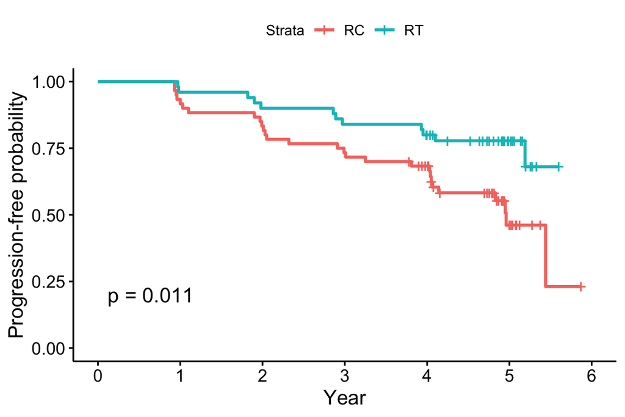

```r
ggsurvplot(KM_target_nontarget_time5_ave, data = AREDS2_shared, pval =TRUE,legend.title="Strata",legend.labs=c("RC","RT"),xlab="Year",ylab="Progression-free probability")
```

### 2.2.2 Table 3 (lower panel)

This section reproduces genetic profile (Table 3 lower panel). Partial data shared is saved under “RealDataAnalysis/data”. Please run last section “Results in section 4.4 of the manuscript” first.

Install “Table1” package if you haven’t:

```r
#library(devtools)
#install_github("emwozniak/Table1")
```

Load library:

```r
catVars <- c("rs1245576", "rs8109218","rs147106198")

# Overall column
tab1 <- CreateTableOne(vars = catVars, data = AREDS2_shared, factorVars = catVars)
tab1
```

```
##
##                   Overall
##   n               110
##   rs1245576 (%)
##      0             37 (33.6)
##      1             57 (51.8)
##      2             16 (14.5)
##   rs8109218 (%)
##      0             44 (40.0)
##      1             54 (49.1)
##      2             12 (10.9)
##   rs147106198 (%)
##      0             49 (44.5)
##      1             53 (48.2)
##      2              8 ( 7.3)
```

```r
# RT, RC and p columns
tab2 <- CreateTableOne(vars = catVars, strata = "time5_ave" , data = AREDS2_shared, factorVars = catVars)
print(tab2, showAllLevels = TRUE,exact = "stage",formatOptions = list(big.mark = ","))
```

```
##                  Stratified by time5_ave
##                   level 0          1          p      test
##   n                     60         50
##   rs1245576 (%)   0     29 (48.3)   8 (16.0)  <0.001
##                   1     29 (48.3)  28 (56.0)
##                   2      2 ( 3.3)  14 (28.0)
##   rs8109218 (%)   0     33 (55.0)  11 (22.0)   0.002
##                   1     23 (38.3)  31 (62.0)
##                   2      4 ( 6.7)   8 (16.0)
##   rs147106198 (%) 0     38 (63.3)  11 (22.0)  <0.001
##                   1     19 (31.7)  34 (68.0)
##                   2      3 ( 5.0)   5 (10.0)
```